# Retro studies

Yuelin Long

February 24, 2019

```r
library(tidyverse)
```

# Problem 1

```r
#Input data
x1 = c(seq(25,75,10),seq(25,75,10))   #Set x1 as age. Use lower limit as the continous variable
x2 = c(rep(0,length(x1)/2),rep(1,length(x1)/2)) #Assume Daily Alcohol Consumption Control Daily Alcohol Consumption 0-79 g to be 0
y = c(0,5,21,34,36,8,1,4,25,42,19,5)
m_y = c(106,164,138,139,88,31,9,26,29,27,18,0)
m = y + m_y
resp = cbind(y, m_y)

#Build prospective model for retrospective study
logit.prosp=glm(resp~x1+x2, family=binomial(link='logit'))
summary(logit.prosp)
```

```
##
## Call:
## glm(formula = resp ~ x1 + x2, family = binomial(link = "logit"))
##
## Deviance Residuals:
##      Min        1Q    Median        3Q       Max
## -2.59974  -1.72957   0.06822   1.19015   1.50808
##
## Coefficients:
##              Estimate Std. Error z value Pr(>|z|)
## (Intercept) -5.023449   0.418224 -12.011   <2e-16 ***
## x1           0.061579   0.007291   8.446   <2e-16 ***
## x2           1.780000   0.187086   9.514   <2e-16 ***
## ---
## Signif. codes:  0 '***' 0.001 '**' 0.01 '*' 0.05 '.' 0.1 ' ' 1
##
## (Dispersion parameter for binomial family taken to be 1)
##
##     Null deviance: 211.608  on 11  degrees of freedom
## Residual deviance:  31.932  on  9  degrees of freedom
## AIC: 78.259
##
## Number of Fisher Scoring iterations: 4
```

### Question 1

Intepretation:

- The coefficient of x1 (b1): Given the daily alcohol consumption fixed, 1 year increase in age would lead to the log odds of getting esophageal cancer to increase by 0.061579;
- The coefficient of x2 (b2): Given the age fixed, the log odds ratio of daily alcohol consumption of more than 80 g would be 1.780000 between case and control groups;
- The intercept does not have any meaning because this is a retrospective study under a prospective model.

# Problem 2

```r
#Input data
x1 = c(rep(0,11),rep(1,10))  # Set x1 to be the species of seed. O. aegyptiaca 75 as 0 and O. aegyptiaca 73 as 1
x2 = c(rep(1,5),rep(0,6),rep(1,5),rep(0,5))  # Set x2 to be the root extract media (cucumber or bean). Bean as 1 and cucumber as 0.
y = c(10,23,23,26,17,5,53,55,32,46,10,8,10,8,23,0,3,22,15,32,3)
m = c(39,62,81,51,39,6,74,72,51,79,13,16,30,28,45,4,12,41,30,51,7)
resp = cbind(y,m - y)

#Build logistic regression model
logit_p2=glm(resp~x1+x2, family=binomial(link='logit'))
summary(logit_p2)
```

```
##
## Call:
## glm(formula = resp ~ x1 + x2, family = binomial(link = "logit"))
##
## Deviance Residuals:
##     Min       1Q   Median       3Q      Max
## -2.3919  -0.9949  -0.3744   0.9831   2.4766
##
## Coefficients:
##             Estimate Std. Error z value Pr(>|z|)
## (Intercept)   0.6347     0.1125   5.644 1.66e-08 ***
## x1           -0.2705     0.1547  -1.748   0.0804 .
## x2           -1.0647     0.1442  -7.383 1.55e-13 ***
## ---
## Signif. codes:  0 '***' 0.001 '**' 0.01 '*' 0.05 '.' 0.1 ' ' 1
##
## (Dispersion parameter for binomial family taken to be 1)
##
##     Null deviance: 98.719  on 20  degrees of freedom
## Residual deviance: 39.686  on 18  degrees of freedom
## AIC: 122.28
##
## Number of Fisher Scoring iterations: 4
```

### Question 1

Intepretation:

- The coefficient of x1 (b1): Given the root extract media fixed, for aegyptiaca 73 seed, the log odds ratio between germination and non-germination seeds is -0.2705;
- The coefficient of x2 (b2): Given the seed species fixed, for bean root extract media, the log odds ratio between germination and non-germination seeds is -1.0647;
- The intercept: For aegyptiaca 75 seed and cucumber root extract media, the log odds ratio between germination and non-germination seeds is 0.6347;

### Question 2

```r
#Goodness of fit

#deviance
res_dev = logit_p2 %>%
  broom::glance() %>%
  select(deviance) %>%
  as.numeric()
res_dev
```

```
## [1] 39.68589
```

```r
#Generalized Pearson chi square statistic
res_pea = sum(residuals(logit_p2, type = "pearson")^2)
res_pea
```

```
## [1] 38.31062
```

```r
#Critical value
n = 21
p = 3
qchisq(0.05,n-p)
```

```
## [1] 9.390455
```

```r
pval=1-pchisq(res_dev,df=n-p)
pval
```

```
## [1] 0.00230277
```

Both deviance and generalized pearson chi square statistics are far greater than critical value. Therefore, reject the null hypothesis and conclude that the fit is bad. The small p value also confirms it.

Use Half-normal plot to see whether it’s overdispersion:

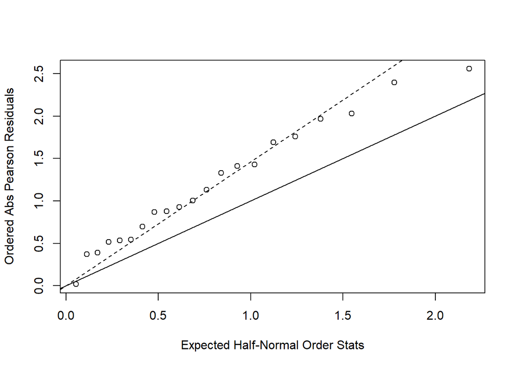

```r
phi=res_pea/(n-p)

plot(qnorm((n+1:n+0.5)/(2*n+1.125)),sort(abs(residuals(logit_p2, type = "pearson"))),xlab='Expected Half-Normal Order Stats',ylab='Ordered Abs Pearson Residuals')
abline(a=0,b=1)
abline(a=0,b=sqrt(phi),lty=2)
```

```r
phi
```

```
## [1] 2.128368
```

As we can see in the plot, the slope of our model deviates from the standard line (y=x), therefore there exists over dispersion. And the dispersion parameter is 2.1283678.

Refit the model:

```r
summary(logit_p2,dispersion=phi)
```

```
##
## Call:
## glm(formula = resp ~ x1 + x2, family = binomial(link = "logit"))
##
## Deviance Residuals:
##     Min       1Q   Median       3Q      Max
## -2.3919  -0.9949  -0.3744   0.9831   2.4766
##
## Coefficients:
##             Estimate Std. Error z value Pr(>|z|)
## (Intercept)   0.6347     0.1641   3.869 0.000109 ***
## x1           -0.2705     0.2257  -1.198 0.230807
## x2           -1.0647     0.2104  -5.061 4.18e-07 ***
## ---
## Signif. codes:  0 '***' 0.001 '**' 0.01 '*' 0.05 '.' 0.1 ' ' 1
##
## (Dispersion parameter for binomial family taken to be 2.128368)
##
##     Null deviance: 98.719  on 20  degrees of freedom
## Residual deviance: 39.686  on 18  degrees of freedom
## AIC: 122.28
##
## Number of Fisher Scoring iterations: 4
```

The intepretation remains unchanged, but the standard of error increased.

Intepretation (same as before):

- The coefficient of x1 (b1): Given the root extract media fixed, for aegyptiaca 73 seed, the log odds ratio between germination and non-germination seeds is -0.2705;
- The coefficient of x2 (b2): Given the seed species fixed, for bean root extract media, the log odds ratio between germination and non-germination seeds is -1.0647;
- The intercept: For aegyptiaca 75 seed and cucumber root extract media, the log odds ratio between germination and non-germination seeds is 0.6347;

### Question 3

Over dispersion may caused by intra-class correlation or hierarchical sampling. The correlation between different group is highly unlikely, therefore the over dispersion should be caused by hierarchical sampling.